# histonePTM R package

```r
library(histonePTM)
library(dplyr)
library(readxl)
```

**A collection of functions to make your life easier.**

# 1. PTMs

Rename PTM strings from `Proline` or `Skyline` to have a shorthanded representation.

### 1.1 `ptm_beautify()`

#### Proline

```r
#PTM from Proline export, from 'modifications' column of sheet 'Best PSM from protein sets'.
PTM_Proline <- 'Propionyl (Any N-term); Propionyl (K1); Butyryl (K10); Butyryl (K11)'

ptm_beautify(PTM_Proline, lookup = histptm_lookup, software = 'Proline', residue = 'keep')
```

```
#> [1] "prNt-K1pr-K10bu-K11bu"
```

```r
ptm_beautify(PTM_Proline, lookup = histptm_lookup, software = 'Proline', residue = 'remove')
```

```
#> [1] "prNt-pr-bu-bu"
```

### Skyline

Skyline PTMs are enclosed between square brackets (e.g. [+28.0313]) and sometimes they are rounded (e.g [+28]). We don’t support rounded numbers since some PTMs like [Ac] and [3Me] are rounded to the same number: +42. Use instead: ‘Peptide Modified Sequence Monoisotopic Masses’ column. Modified peptides in the ‘isolation list’ output file (‘Comment’ column) from Skyline always contains monoisotopic masses of PTMs as well.

```r
PTM_Skyline <- "K[+124.05243]SVPSTGGVK[+56.026215]K[+56.026215]PHR"


ptm_beautify(PTM_Skyline, lookup = shorthistptm_mass, software = 'Skyline', residue = 'keep')
```

```
#> [1] "prNt-KcrSVPSTGGVKprKprPHR"
```

```r
ptm_beautify(PTM_Skyline, lookup = shorthistptm_mass, software = 'Skyline', residue = 'remove')
```

```
#> [1] "prNt-cr-pr-pr"
```

### 1.2 `misc_clearLabeling`

```r
misc_clearLabeling("prNt-cr-pr-pr")
```

```
#> ! Please provide valid rules or specify a supported labeling argument.
#> [1] "prNt-cr-pr-pr"
```

### 1.3 `ptm_toProForma()`

Convert PTM string to [ProForma](https://www.psidev.info/proforma) ProForma (Proteoform and Peptidoform Notation)

```r
histonePTM::ptm_toProForma(seq = "KSAPATGGVKKPHR",
                mod = "Propionyl (Any N-term); Lactyl (K1); Dimethyl (K10); Propionyl (K11)")
```

```
#> [1] "[UNIMOD:58]-K[UNIMOD:2114]SAPATGGVK[UNIMOD:36]K[UNIMOD:58]PHR"
```

```r
ptm_toProForma(seq = "KSAPATGGVKKPHR",
               mod = "TMAyl_correct (Any N-term); Butyryl (K1); Trimethyl (K10); Propionyl (K11)")
```

```
#> [1] "[TMAyl_correct]-K[UNIMOD:1289]SAPATGGVK[UNIMOD:37]K[UNIMOD:58]PHR"
```

```r
ptm_toProForma(  seq = "KQLATKVAR",
                 mod = "Propionyl (Any N-term); Propionyl (K1); Propionyl (K6)")
```

```
#> [1] "[UNIMOD:58]-K[UNIMOD:58]QLATK[UNIMOD:58]VAR"
```

### 1.4 `ptm_labelingAssessment()`

Lysine derivatization can go rogue and can label other residues such as S, T, and Y. When using propionic anhydride, this is called ’ Overpropionylation’. Hydroxylamine is used to remove this adventitous labeling, so-called “reverse propionylation’. This function help for a quick visual review to see if overpropionylation is limited or enormous.

This for sure assume that the database search results are ran with `Propionyl (STY)` or any other labeling modification is selected.

```
#> $plot
#> $plot$KSAPATGGVKKPHR
```

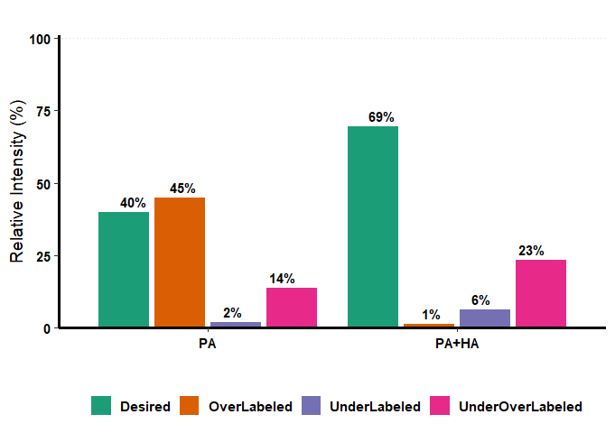

```r
df_label <- readxl::read_excel(path = './docs/labeling_comparison.xlsx',
                               sheet = 'Best PSM from protein sets')


ptm_labelingAssessment(df = df_label,
                       seq_col = sequence,
                       seq = 'KSAPATGGVKKPHR',
                       ptm_col = modifications,
                       show_text = TRUE,
                       type = "dodged",
                       int_col = dplyr::starts_with('abundance_'))['plot']
```

# 2.MGF-related

Some functions that operate on `MGF` (Mascot Generic Format) files.

## 2.1 `mgf_searchDiagIon()`

It searches in all MS/MS scan for pre-defined `m/z` of diagnostic ions. It reports their presence and their relative intensities relative to the base peak.

```r
mgf_file <- './docs/toyExample.mgf'

List_DiagIons <- c(156.102, 126.091)

tolerance = 0.001

mgf_searchDiagIon(mgf_file = mgf_file,
                  diag_ion = List_DiagIons,
                  tol = tolerance,
                  save_file = FALSE)
```

```
#> # A tibble: 29 × 7
#>    file       diag_ion diag_relint prec_mz    rt  scan prec_z
#>    <chr>         <dbl>       <dbl>   <dbl> <dbl> <int>  <int>
#>  1 toyExample     126.       0.902    822.  33.7 15338      2
#>  2 toyExample     156.       1        508.  17.4  5920      2
#>  3 toyExample     156.       0.007    375.  75.5 26917      2
#>  4 toyExample     126.       0.032    375.  75.5 26917      2
#>  5 toyExample     156.       1        398.  18.6  6289      4
#>  6 toyExample     126.       0.043    398.  18.6  6289      4
#>  7 toyExample     126.       1        395.  18.1  6137      4
#>  8 toyExample     156.       0.182    404.  75.7 26987      2
#>  9 toyExample     126.       0.021    404.  75.7 26987      2
#> 10 toyExample     156.       0.003    356.  75.8 27008      2
#> # ℹ 19 more rows
```

## 2.1 `mgf_extractMS2scan()`

It extracts specific scan(s) as dataframes with columns: 1. `mgf`: Name of the mgf file with extension. 2. `m/z`: 3. `intensity` 4. `scan`

```r
scans = c(5920, 6289)
mgf_extractMS2scan(mgf_file ='./docs/toyExample.mgf',
                   scan= scans,
                   save_file = FALSE, #save results as csv file
                   export_mgf = FALSE #save selected scans as mgf file
                   )
```

```
#> Reading toyExample.mgf...
#> ✔ 'toyExample.mgf' is converted into a 'Spectra' object.
#> # A tibble: 120 × 4
#>    mgf         scan    mz intensity
#>    <chr>      <int> <dbl>     <dbl>
#>  1 toyExample  5920  84.1     1714.
#>  2 toyExample  5920  92.5      897.
#>  3 toyExample  5920  94.2      841.
#>  4 toyExample  5920 120.       925.
#>  5 toyExample  5920 144.       819.
#>  6 toyExample  5920 156.      7279.
#>  7 toyExample  5920 169.       893.
#>  8 toyExample  5920 173.      1792.
#>  9 toyExample  5920 175.      1018.
#> 10 toyExample  5920 202.       815.
#> # ℹ 110 more rows
```

## 2.2 `mgf_extractScan()`

Same function as above but faster (`Python`-based ran in `R`).

```r
scan15338 <- mgf_extractScan(mgf_file = './docs/toyExample.mgf', scan = 15338)

head(scan15338)
```

```
#> # A tibble: 6 × 4
#>   mgf         scan    mz intensity
#>   <chr>      <int> <dbl>     <dbl>
#> 1 toyExample 15338  84.1  6366502.
#> 2 toyExample 15338  86.4   534698.
#> 3 toyExample 15338 110.    644364.
#> 4 toyExample 15338 110.    387260.
#> 5 toyExample 15338 112.    595217.
#> 6 toyExample 15338 112.    327108.
```

# 3.Plots

It generates fragment `b` and `y` fragment ions and draws annotated spectrum. This function relies on the `spectrum_utils` pyhton package.

## 3.1 `plot_annotateSpectrum()`

```
#> 'myplot.png' spectrum is saved sucessfully.
```

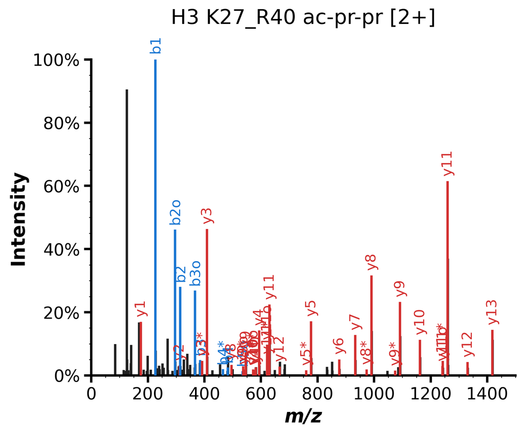

```r
plot_annotateSpectrum(
  Profrma_peptide = "K[+98.03678]SAPATGGVK[+56.02622]K[+56.02622]PHR",
prec_mz = 822.465,
prec_z = 2,
mz = scan15338$mz,
intensity = scan15338$intensity,
title= "H3 K27_R40 ac-pr-pr [2+]",
output_plot_name = "myplot.png")
```

## 3.2 `plot_scheduledPRM()`

It counts and plots the number of precursors monitored per time unit in scheduled PRM experiment. It takes a list of `m/z` and `RT` as input as well as the retention time window size and peak width.

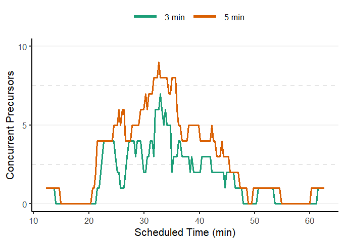

```r
peptides_df <- data.frame(

moz= c(553.9903,830.4623,844.4781,549.3170,
         837.4703,822.4650,836.4807,543.9861,
         548.6583,829.4728,844.4781,858.4938,
         558.6614,563.3330,851.4865,836.4807,
         850.4963,553.3290,558.0017,843.4885,
         487.2567,644.8226,683.8279,547.2980,
         669.8381,699.3384,726.8357,622.8535,
         776.9298),


rt= c(26.79,30.15,36.62,23.51,32.60,
       31.58,37.41,23.94,23.83,33.38,
       35.11,41.70,28.49,28.32,37.64,
       40.43,46.31,33.47,33.31,42.83,
       12.22,23.02,27.85,31.76,34.15,
       40.01,44.72,52.09,62.64)
)


plot_scheduledPRM(df = peptides_df,
                  rt_col = rt,
                  mz_col = moz,
                  rt_window = c(3, 5),
                  peak_width = 0.3,
                  save_plot = FALSE)
```

## 3.3 `plot_scheduledPRMranges()`

A plot as above, but shows the the rt range of each `m/z` allowing visually to see how many concurrent precursor are overlapping at a certain time point.

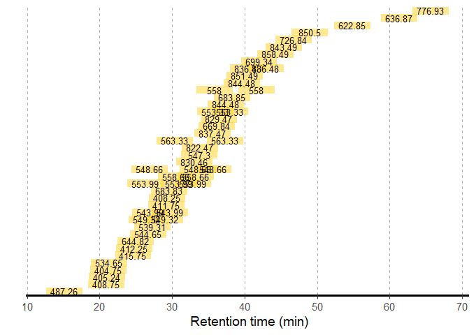

```r
df <- readr::read_csv('./docs/isolation_list.csv', show_col_types = FALSE)
plot_schdueldPRMranges(df = df,
                        tr_start = `Start [min]`,
                        tr_end = `End [min]`,
                        y_axis = `Mass [m/z]`,
                        label = `Mass [m/z]`,
                        save_plot = FALSE  )
```

## 3.4 `plot_mirrorSpectra()`

It mirrors two spectra, It takes as input `m/z` and `intensity` of each fragment ion. Another necessary column to provide is the `grouping_col` that contain the source of each fragment ion. The those tags should be specifified in `top_spec` and `bottom_spec`. The function does not have an aption to annotated the spectra.

```r
scanraw <- mgf_extractMS2scan(mgf_file = './docs/raw.mgf', scan = 8730)
```

```
#> Reading raw.mgf...
#> ✔ 'raw.mgf' is converted into a 'Spectra' object.
```

```r
scanprocessed <- mgf_extractMS2scan(mgf_file = './docs/SN_MH.mgf', scan = 8730)
```

```
#> Reading SN_MH.mgf...
#> ✔ 'SN_MH.mgf' is converted into a 'Spectra' object.
```

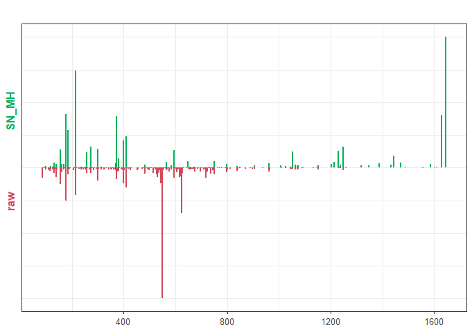

```r
df_mirror <- bind_rows(scanraw, scanprocessed)

plot_mirrorSpectra(data = df_mirror,
                   mz_col = mz,
                   intensity_col = intensity,
                   grouping_col = mgf,
                   top_spec = "SN_MH",
                   bottom_spec = "raw",
                   title = "")
```

## 3.5 `plot_H3vsH33()`

A plot that shows relative abundance of canonical H3 versus H3.3 based on H3 K27-R40 peptidoforms.

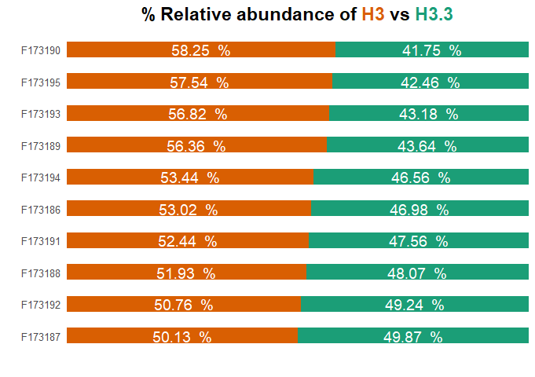

```r
df_H3 <- readxl::read_excel(path = './docs/20231102_H3_STR_SUM.xlsx',
                               sheet = 'Best PSM from protein sets')

plot_H3vsH33(df = df_H3, seq_col = sequence, seq_ptm_col = modifications, int_col = starts_with('abundance_'), save_plot = FALSE, save_file = FALSE)['plot']
```

## 3.6 `plot_jitterbarIntvsPTM()`

A bar plot with scattered points showing the mean/median of the measurement of each condition.

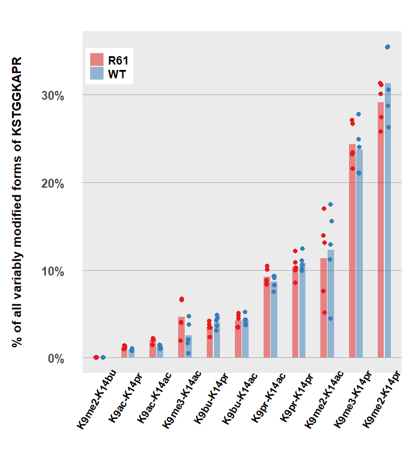

```r
df_K9K14_long <- readxl::read_excel(path = './docs/K9K14_long.xlsx')

plot_jitterbarIntvsPTM(dataset = df_K9K14_long,
                       x_axis = PTM,
                       y_axis = intensity,
                       condition = Condition,
                       id_col = sequence
                       )['plots'][[1]]
```

## 3.7 `plot_intDensity()`

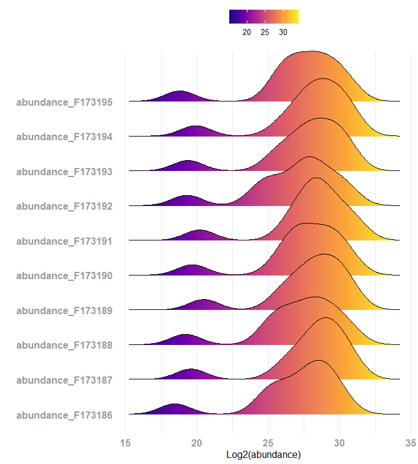

```r
df <- read_xlsx(path = './docs/K9K14.xlsx')
plot_intDensity(df = df, int_col = dplyr::starts_with("abundance_"))
```

# 4.Quantification

## 4.1 `quant_relIntensity()`

# Calculation of Relative Intensity

Calculates the relative intensity of each peptide in each sample based on the following equation:

$$\frac{{\rm{intensity}}\;{\rm{of}}\;{\rm{a}}\;{\rm{peptidoform}}}
{\Sigma
\;{\rm{intensities}}\;{\rm{of}}\;{\rm{all}}\;{\rm{observed}}\;{\rm{modified}}\;{\rm{forms}}\;{\rm{of}}\;{\rm{the}}\;{\rm{peptide}}}.$$

```r
df_K9K14 <- readxl::read_excel(path = './docs/K9K14.xlsx')

df_K9K14_norm <- quant_relIntensity(df = df_K9K14,
                   select_cols = starts_with('abundance_'),
                   grouping_var = sequence)


#before normalization

df_K9K14 |> select(starts_with('abundance_')) |> head()
```

```
#> # A tibble: 6 × 10
#>   abundance_F173186 abundance_F173188 abundance_F173189 abundance_F173192
#>               <dbl>             <dbl>             <dbl>             <dbl>
#> 1        475453472         514254080         958833792         182273696
#> 2         38940812          43781780          90300080          57599136
#> 3       1124633344        1632991360        1767608320        1452094720
#> 4         75190408          77742064         233615456          21107264
#> 5           366894.           611339.          1479332.           653948.
#> 6        775680448        1144565888        1296215680        1139372160
#> # ℹ 6 more variables: abundance_F173193 <dbl>, abundance_F173194 <dbl>,
#> #   abundance_F173191 <dbl>, abundance_F173187 <dbl>, abundance_F173190 <dbl>,
#> #   abundance_F173195 <dbl>
```

```r
#after normalization
df_K9K14_norm |> select(starts_with('abundance_')) |> head()
```

```
#> # A tibble: 6 × 10
#>   abundance_F173186 abundance_F173188 abundance_F173189 abundance_F173192
#>               <dbl>             <dbl>             <dbl>             <dbl>
#> 1         0.129              0.112             0.156             0.0445
#> 2         0.0106             0.00952           0.0147            0.0141
#> 3         0.306              0.355             0.287             0.354
#> 4         0.0204             0.0169            0.0380            0.00515
#> 5         0.0000998          0.000133          0.000240          0.000160
#> 6         0.211              0.249             0.211             0.278
#> # ℹ 6 more variables: abundance_F173193 <dbl>, abundance_F173194 <dbl>,
#> #   abundance_F173191 <dbl>, abundance_F173187 <dbl>, abundance_F173190 <dbl>,
#> #   abundance_F173195 <dbl>
```

# 5.Spectral Library

## 5.1 `blib_seamlessIDswap()`

When building a spectral library, `Skyline` can create two libraries. The main `*.blib` library and the second `*_redundant.blib`. In histones, some times the best representative spectrum could be present in the redundant library not in the main one. To keep everything neat, this function takes the identification from the redundant library and place it in the main library and place the main identification in the redundant library. To confirm the successful switch, the new identification will be highlighted in red and the other will turn black.

```r
#blib_seamlessIDswap(db_main = , db_redundant = , rt = , mz = , tol = , file =  )
```

# 6.Sequence Organization & Manipulation

## 6.1 `seq_AAcountplot()`

Count the occurrences of a residue in a sequence and compare it with other sequences.

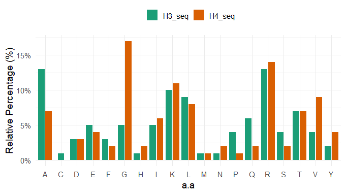

```
#> # A tibble: 37 × 3
#>    seq    a.a   relative_percent
#>    <chr>  <chr>            <dbl>
#>  1 H3_seq A                   13
#>  2 H3_seq R                   13
#>  3 H3_seq T                    7
#>  4 H3_seq K                   10
#>  5 H3_seq Q                    6
#>  6 H3_seq S                    4
#>  7 H3_seq G                    5
#>  8 H3_seq P                    4
#>  9 H3_seq L                    9
#> 10 H3_seq V                    4
#> # ℹ 27 more rows
```

```r
H3_seq <-  "ARTKQTARKSTGGKAPRKQLATKAARKSAPATGGVKKPHRYRPGTVALREIRRYQKSTELLIRKLPFQRLVREIAQDFKTDLRFQSSAVMALQEACEAYLVGLFEDTNLCAIHAKRVTIMPKDIQLARRIRGERA"

H4_seq <-  "SGRGKGGKGLGKGGAKRHRKVLRDNIQGITKPAIRRLARRGGVKRISGLIYEETRGVLKVFLENVIRDAVTYTEHAKRKTVTAMDVVYALKRQGRTLYGFGG"

seq_AAcountplot(H3_seq, H4_seq, plot = TRUE)
```

## `seq_getHistPeptide()`

```r
df_new <- seq_getHistPeptide(df = df_H3, seq_col = sequence, histoneProtein = "H4")
```

```
#> H4 histone peptides were extracted.
```

```r
unique(df_new$sequence)
```

```
#> [1] "ISGLIYEETR"     "DAVTYTEHAKR"    "DNIQGITKPAIR"   "GKGGKGLGKGGAKR"
#> [5] "KTVTAMDVVYALKR"
```

# 7.Scraping Online Data

## 7.1 `litReview()`

A quick literature review from [PubMed](https://pubmed.ncbi.nlm.nih.gov/)

```r
litReview(start = 2023, end = 2024, term = "Tiziana Bonaldi[au]")
```

```
#> $Data
#> # A tibble: 22 × 3
#>     year id       title
#>    <int> <chr>    <chr>
#>  1  2023 38124114 A comprehensive characterisation of phaeochromocytoma and par…
#>  2  2023 38102575 Multi-omics integrative modelling for stereotactic body radio…
#>  3  2023 38028201 Unveiling the role of PUS7-mediated pseudouridylation in host…
#>  4  2023 38019906 GTF2I dosage regulates neuronal differentiation and social be…
#>  5  2023 37727062 Proteomics contributions to epigenetic drug discovery.
#>  6  2023 37665465 Mass Spectrometry-Based Analysis of Histone Posttranslational…
#>  7  2023 37294917 Lipid nanoparticles allow efficient and harmless ex vivo gene…
#>  8  2023 37146898 Detection and quantification of the histone code in the funga…
#>  9  2023 36810679 Methylation of CENP-A/Cse4 on arginine 143 and lysine 131 reg…
#> 10  2023 36697763 A truncated and catalytically inactive isoform of KDM5B histo…
#> # ℹ 12 more rows
#>
#> $Summary
#>
#> 2023 2024
#>   14    8
```

## 7.2 `ptm_Uniprot()`

It fetches PTMs identified by proteomics from [Uniprot](https://www.uniprot.org/) with the associated metadata.

```r
accession <- 'P84243' #Histone H3.3

ptm_Uniprot(Uniprot_accession = accession)
```

```
#> # A tibble: 38 × 25
#>    type           begin end   xrefs_name xrefs_id    xrefs_url    evidences_code
#>    <chr>          <chr> <chr> <chr>      <chr>       <chr>        <chr>
#>  1 PROTEOMICS_PTM 52    60    Proteomes  UP000005640 https://www… ECO:0007829
#>  2 PROTEOMICS_PTM 28    41    Proteomes  UP000005640 https://www… ECO:0007829
#>  3 PROTEOMICS_PTM 75    82    Proteomes  UP000005640 https://www… ECO:0007829
#>  4 PROTEOMICS_PTM 16    24    Proteomes  UP000005640 https://www… ECO:0007829
#>  5 PROTEOMICS_PTM 55    64    Proteomes  UP000005640 https://www… ECO:0007829
#>  6 PROTEOMICS_PTM 55    64    Proteomes  UP000005640 https://www… ECO:0007829
#>  7 PROTEOMICS_PTM 55    64    Proteomes  UP000005640 https://www… ECO:0007829
#>  8 PROTEOMICS_PTM 55    64    Proteomes  UP000005640 https://www… ECO:0007829
#>  9 PROTEOMICS_PTM 55    64    Proteomes  UP000005640 https://www… ECO:0007829
#> 10 PROTEOMICS_PTM 55    64    Proteomes  UP000005640 https://www… ECO:0007829
#> # ℹ 28 more rows
#> # ℹ 18 more variables: evidences_source_id <chr>, evidences_source_url <chr>,
#> #   peptide <chr>, unique <lgl>, name <chr>, position <int>, sources <chr>,
#> #   dbReferences_id <chr>, `dbReferences_properties_Pubmed ID` <chr>,
#> #   `dbReferences_properties_Confidence score` <chr>,
#> #   `dbReferences_properties_Site q value` <chr>,
#> #   `dbReferences_properties_Sumo isoforms` <chr>, …
```